# LME Inter-Item Timing (winsorized)

Tyler Peckenpaugh

3/5/2019

# Inter-item timing analyses

Mean inter-reading time (IRT) is a measure of the amount of time in ms between when a subject stops speaking during a cold reading and when they begin speaking for a previewed reading.

Subjects were asked to read each sentence twice, once with no preview at all, and then again after unlimited preview. IRT is meant to represent their chosen preview time for the second reading.

## Mean and SD of IRT by condition

Mean inter-reading time (IRT) in ms

|  | mean |
| --- | --- |
| -GP -Q | 987.600 |
| -GP +Q | 1062.969 |
| +GP -Q | 1094.249 |
| +GP +Q | 1024.491 |

Standard deviation inter-reading time (IRT) in ms

|  | -Q | +Q |
| --- | --- | --- |
| -GP | 917.0037 | 866.9178 |
| +GP | 995.7657 | 844.3854 |

## boxplot of mean inter-item time by condition

Inter reading time (IRT) in ms

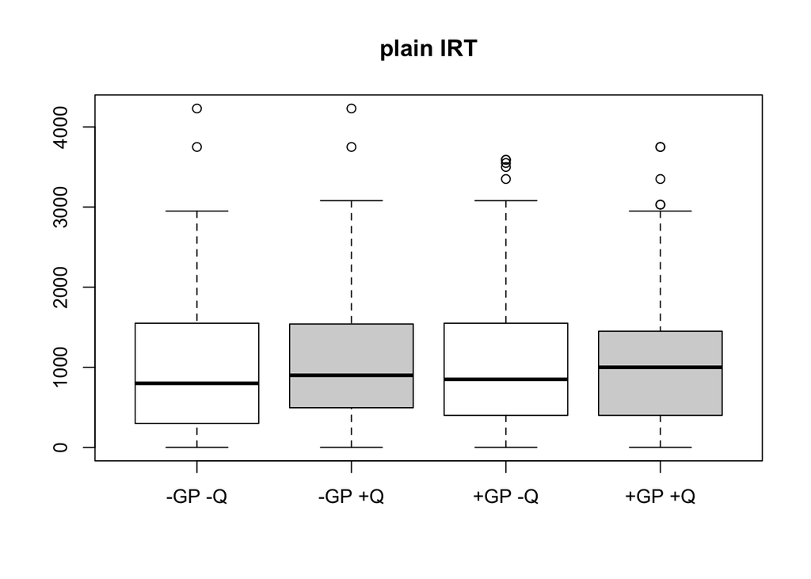

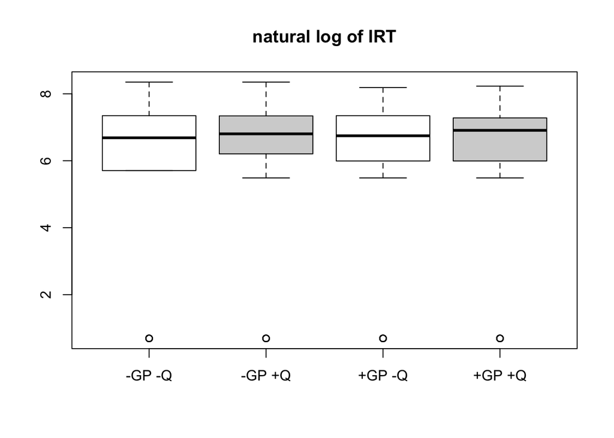

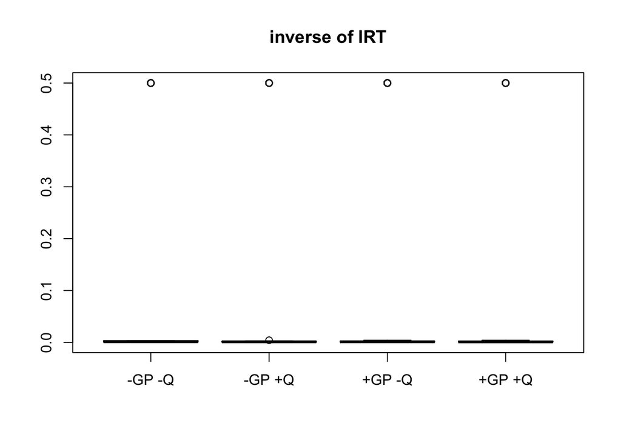

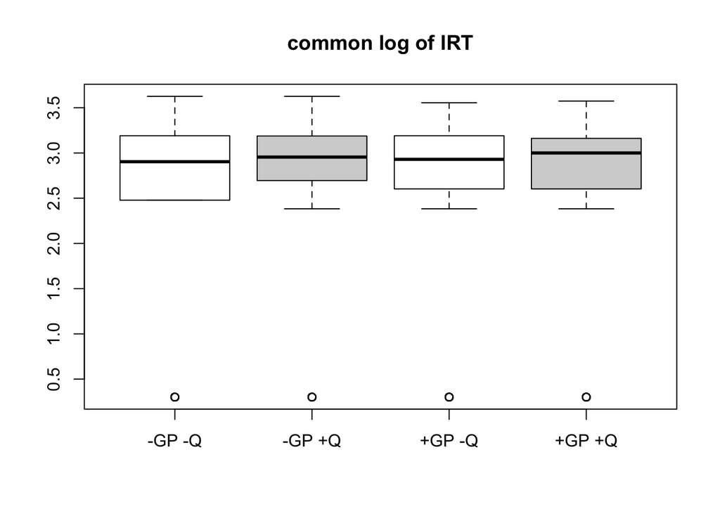

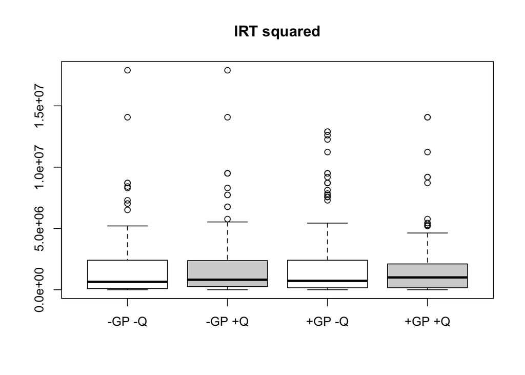

# Models

## All participants

### Full model

```r
summary(models.timing)
```

```
## Linear mixed model fit by maximum likelihood . t-tests use
##   Satterthwaite's method [lmerModLmerTest]
## Formula: inter_reading ~ GP_condition * Q_condition + (1 + GP_condition *
##     Q_condition | participant) + (1 + GP_condition * Q_condition |
##     item)
##    Data: inter_item_timings
## Control: lmerControl(optCtrl = list(maxfun = 2e+12))
##
##      AIC      BIC   logLik deviance df.resid
##   7967.9   8073.2  -3959.0   7917.9      473
##
## Scaled residuals:
##      Min       1Q   Median       3Q      Max
## -2.54468 -0.70334 -0.07505  0.74446  2.57200
##
## Random effects:
##  Groups      Name                             Variance Std.Dev. Corr
##  participant (Intercept)                      521907   722.43
##              GP_conditionTRUE                  28371   168.44    0.39
##              Q_conditionTRUE                   18133   134.66   -0.61
##              GP_conditionTRUE:Q_conditionTRUE 180316   424.64   -0.17
##  item        (Intercept)                           0     0.00
##              GP_conditionTRUE                  20463   143.05     NaN
##              Q_conditionTRUE                    6827    82.63     NaN
##              GP_conditionTRUE:Q_conditionTRUE  21878   147.91     NaN
##  Residual                                     367635   606.33
##
##
##
##   0.49
##  -0.97 -0.67
##
##
##   1.00
##  -1.00 -1.00
##
## Number of obs: 498, groups:  participant, 33; item, 16
##
## Fixed effects:
##                                  Estimate Std. Error      df t value
## (Intercept)                        998.86     137.33   31.91   7.273
## GP_conditionTRUE                   138.53      90.00   43.99   1.539
## Q_conditionTRUE                     89.36      83.08   68.72   1.076
## GP_conditionTRUE:Q_conditionTRUE  -189.83     137.01   31.26  -1.386
##                                  Pr(>|t|)
## (Intercept)                      2.94e-08 ***
## GP_conditionTRUE                    0.131
## Q_conditionTRUE                     0.286
## GP_conditionTRUE:Q_conditionTRUE    0.176
## ---
## Signif. codes:  0 '***' 0.001 '**' 0.01 '*' 0.05 '.' 0.1 ' ' 1
##
## Correlation of Fixed Effects:
##             (Intr) GP_cTRUE Q_TRUE
## GP_cndtTRUE -0.128
## Q_cndtnTRUE -0.424  0.549
## GP_TRUE:Q_T  0.076 -0.763   -0.691
## convergence code: 0
## singular fit
```

### Full model (natural log)

```r
summary(models.timingLn)
```

```
## Linear mixed model fit by maximum likelihood . t-tests use
##   Satterthwaite's method [lmerModLmerTest]
## Formula:
## inter_reading.ln ~ GP_condition * Q_condition + (1 + GP_condition *
##     Q_condition | participant) + (1 + GP_condition * Q_condition |
##     item)
##    Data: inter_item_timings
## Control: lmerControl(optCtrl = list(maxfun = 2e+12))
##
##      AIC      BIC   logLik deviance df.resid
##   2212.8   2318.1  -1081.4   2162.8      473
##
## Scaled residuals:
##     Min      1Q  Median      3Q     Max
## -2.7199 -0.3075  0.1539  0.4697  2.5225
##
## Random effects:
##  Groups      Name                             Variance Std.Dev. Corr
##  participant (Intercept)                      4.45329  2.1103
##              GP_conditionTRUE                 0.79268  0.8903   -0.69
##              Q_conditionTRUE                  0.56730  0.7532   -0.96
##              GP_conditionTRUE:Q_conditionTRUE 1.36482  1.1683    0.79
##  item        (Intercept)                      0.05016  0.2240
##              GP_conditionTRUE                 0.45504  0.6746   -1.00
##              Q_conditionTRUE                  0.12824  0.3581   -1.00
##              GP_conditionTRUE:Q_conditionTRUE 0.65407  0.8087    1.00
##  Residual                                     3.67133  1.9161
##
##
##
##   0.86
##  -0.92 -0.93
##
##
##   1.00
##  -1.00 -1.00
##
## Number of obs: 498, groups:  participant, 33; item, 16
##
## Fixed effects:
##                                  Estimate Std. Error      df t value
## (Intercept)                        5.3352     0.4107 32.5560  12.990
## GP_conditionTRUE                   0.3872     0.3350 16.0622   1.156
## Q_conditionTRUE                    0.5944     0.2907 37.1847   2.045
## GP_conditionTRUE:Q_conditionTRUE  -0.5291     0.4484 19.3639  -1.180
##                                  Pr(>|t|)
## (Intercept)                      1.99e-14 ***
## GP_conditionTRUE                    0.265
## Q_conditionTRUE                     0.048 *
## GP_conditionTRUE:Q_conditionTRUE    0.252
## ---
## Signif. codes:  0 '***' 0.001 '**' 0.01 '*' 0.05 '.' 0.1 ' ' 1
##
## Correlation of Fixed Effects:
##             (Intr) GP_cTRUE Q_TRUE
## GP_cndtTRUE -0.577
## Q_cndtnTRUE -0.683  0.648
## GP_TRUE:Q_T  0.546 -0.818   -0.784
## convergence code: 0
## singular fit
```

### Full model (common log)

```r
summary(models.timingLg10)
```

```
## Linear mixed model fit by maximum likelihood . t-tests use
##   Satterthwaite's method [lmerModLmerTest]
## Formula:
## inter_reading.log10 ~ GP_condition * Q_condition + (1 + GP_condition *
##     Q_condition | participant) + (1 + GP_condition * Q_condition |
##     item)
##    Data: inter_item_timings
## Control: lmerControl(optCtrl = list(maxfun = 2e+12))
##
##      AIC      BIC   logLik deviance df.resid
##   1382.1   1487.4   -666.0   1332.1      473
##
## Scaled residuals:
##     Min      1Q  Median      3Q     Max
## -2.7180 -0.3063  0.1557  0.4674  2.5243
##
## Random effects:
##  Groups      Name                             Variance Std.Dev. Corr
##  participant (Intercept)                      0.84601  0.91979
##              GP_conditionTRUE                 0.15124  0.38889  -0.70
##              Q_conditionTRUE                  0.10816  0.32888  -0.96
##              GP_conditionTRUE:Q_conditionTRUE 0.25986  0.50977   0.79
##  item        (Intercept)                      0.00919  0.09587
##              GP_conditionTRUE                 0.08359  0.28912  -1.00
##              Q_conditionTRUE                  0.02368  0.15389  -1.00
##              GP_conditionTRUE:Q_conditionTRUE 0.12033  0.34689   1.00
##  Residual                                     0.69222  0.83199
##
##
##
##   0.87
##  -0.92 -0.93
##
##
##   1.00
##  -1.00 -1.00
##
## Number of obs: 498, groups:  participant, 33; item, 16
##
## Fixed effects:
##                                  Estimate Std. Error      df t value
## (Intercept)                        2.3169     0.1788 32.3121  12.956
## GP_conditionTRUE                   0.1683     0.1452 16.1327   1.159
## Q_conditionTRUE                    0.2583     0.1263 37.3416   2.046
## GP_conditionTRUE:Q_conditionTRUE  -0.2299     0.1944 19.4796  -1.182
##                                  Pr(>|t|)
## (Intercept)                      2.42e-14 ***
## GP_conditionTRUE                   0.2633
## Q_conditionTRUE                    0.0479 *
## GP_conditionTRUE:Q_conditionTRUE   0.2513
## ---
## Signif. codes:  0 '***' 0.001 '**' 0.01 '*' 0.05 '.' 0.1 ' ' 1
##
## Correlation of Fixed Effects:
##             (Intr) GP_cTRUE Q_TRUE
## GP_cndtTRUE -0.579
## Q_cndtnTRUE -0.683  0.648
## GP_TRUE:Q_T  0.547 -0.817   -0.784
## convergence code: 0
## singular fit
```

### Full model (inverse)

```r
summary(models.timingInv)
```

```
## Linear mixed model fit by maximum likelihood . t-tests use
##   Satterthwaite's method [lmerModLmerTest]
## Formula:
## inter_reading.inverse ~ GP_condition * Q_condition + (1 + GP_condition *
##     Q_condition | participant) + (1 + GP_condition * Q_condition |
##     item)
##    Data: inter_item_timings
## Control: lmerControl(optCtrl = list(maxfun = 2e+12))
##
##      AIC      BIC   logLik deviance df.resid
##   -293.2   -188.0    171.6   -343.2      473
##
## Scaled residuals:
##      Min       1Q   Median       3Q      Max
## -2.71315 -0.44204 -0.07052  0.03174  2.72419
##
## Random effects:
##  Groups      Name                             Variance  Std.Dev. Corr
##  participant (Intercept)                      0.0242948 0.15587
##              GP_conditionTRUE                 0.0071488 0.08455  -0.73
##              Q_conditionTRUE                  0.0037812 0.06149  -0.97
##              GP_conditionTRUE:Q_conditionTRUE 0.0098771 0.09938   0.89
##  item        (Intercept)                      0.0003657 0.01912
##              GP_conditionTRUE                 0.0030871 0.05556  -1.00
##              Q_conditionTRUE                  0.0005187 0.02278  -1.00
##              GP_conditionTRUE:Q_conditionTRUE 0.0045387 0.06737   1.00
##  Residual                                     0.0242665 0.15578
##
##
##
##   0.87
##  -0.91 -0.98
##
##
##   1.00
##  -1.00 -1.00
##
## Number of obs: 498, groups:  participant, 33; item, 16
##
## Fixed effects:
##                                  Estimate Std. Error       df t value
## (Intercept)                       0.13285    0.03101 32.31910   4.284
## GP_conditionTRUE                 -0.02819    0.02838 17.68716  -0.993
## Q_conditionTRUE                  -0.04802    0.02322 43.80827  -2.068
## GP_conditionTRUE:Q_conditionTRUE  0.03783    0.03699 19.48543   1.023
##                                  Pr(>|t|)
## (Intercept)                      0.000154 ***
## GP_conditionTRUE                 0.333946
## Q_conditionTRUE                  0.044581 *
## GP_conditionTRUE:Q_conditionTRUE 0.319014
## ---
## Signif. codes:  0 '***' 0.001 '**' 0.01 '*' 0.05 '.' 0.1 ' ' 1
##
## Correlation of Fixed Effects:
##             (Intr) GP_cTRUE Q_TRUE
## GP_cndtTRUE -0.637
## Q_cndtnTRUE -0.708  0.634
## GP_TRUE:Q_T  0.612 -0.821   -0.779
## convergence code: 0
## singular fit
```

### Full model (squared)

```r
summary(models.timingSq)
```

```
## Linear mixed model fit by maximum likelihood . t-tests use
##   Satterthwaite's method [lmerModLmerTest]
## Formula:
## inter_reading.sqred ~ GP_condition * Q_condition + (1 + GP_condition *
##     Q_condition | participant) + (1 + GP_condition * Q_condition |
##     item)
##    Data: inter_item_timings
## Control: lmerControl(optCtrl = list(maxfun = 2e+12))
##
##      AIC      BIC   logLik deviance df.resid
##  16035.2  16140.4  -7992.6  15985.2      473
##
## Scaled residuals:
##     Min      1Q  Median      3Q     Max
## -3.1359 -0.3596 -0.1140  0.3072  4.6582
##
## Random effects:
##  Groups      Name                             Variance  Std.Dev. Corr
##  participant (Intercept)                      4.688e+12 2165187
##              GP_conditionTRUE                 1.017e+12 1008435   0.44
##              Q_conditionTRUE                  2.103e+11  458535  -0.21
##              GP_conditionTRUE:Q_conditionTRUE 4.074e+12 2018387  -0.22
##  item        (Intercept)                      1.528e+10  123611
##              GP_conditionTRUE                 2.402e+11  490084  -0.37
##              Q_conditionTRUE                  1.797e+11  423878  -0.95
##              GP_conditionTRUE:Q_conditionTRUE 4.201e+11  648184   0.81
##  Residual                                     3.906e+12 1976272
##
##
##
##   0.79
##  -0.97 -0.91
##
##
##   0.65
##  -0.84 -0.96
##
## Number of obs: 498, groups:  participant, 33; item, 16
##
## Fixed effects:
##                                    Estimate Std. Error         df t value
## (Intercept)                      1914293.39  418741.88      30.95   4.572
## GP_conditionTRUE                  466429.68  330691.62      28.99   1.410
## Q_conditionTRUE                    82061.55  283860.85      21.10   0.289
## GP_conditionTRUE:Q_conditionTRUE -603039.27  526499.17      26.93  -1.145
##                                  Pr(>|t|)
## (Intercept)                      7.33e-05 ***
## GP_conditionTRUE                    0.169
## Q_conditionTRUE                     0.775
## GP_conditionTRUE:Q_conditionTRUE    0.262
## ---
## Signif. codes:  0 '***' 0.001 '**' 0.01 '*' 0.05 '.' 0.1 ' ' 1
##
## Correlation of Fixed Effects:
##             (Intr) GP_cTRUE Q_TRUE
## GP_cndtTRUE -0.033
## Q_cndtnTRUE -0.350  0.551
## GP_TRUE:Q_T  0.032 -0.808   -0.703
## convergence code: 0
## singular fit
```

```r
summary(models.timingNoInt)
```

```
## Linear mixed model fit by maximum likelihood . t-tests use
##   Satterthwaite's method [lmerModLmerTest]
## Formula: inter_reading ~ GP_condition * Q_condition + (1 + GP_condition *
##     Q_condition | participant) + (1 + GP_condition * Q_condition |
##     item)
##    Data: inter_item_timings
## Control: lmerControl(optCtrl = list(maxfun = 2e+12))
##
##      AIC      BIC   logLik deviance df.resid
##   7967.9   8073.2  -3959.0   7917.9      473
##
## Scaled residuals:
##      Min       1Q   Median       3Q      Max
## -2.54468 -0.70334 -0.07505  0.74446  2.57200
##
## Random effects:
##  Groups      Name                             Variance Std.Dev. Corr
##  participant (Intercept)                      521907   722.43
##              GP_conditionTRUE                  28371   168.44    0.39
##              Q_conditionTRUE                   18133   134.66   -0.61
##              GP_conditionTRUE:Q_conditionTRUE 180316   424.64   -0.17
##  item        (Intercept)                           0     0.00
##              GP_conditionTRUE                  20463   143.05     NaN
##              Q_conditionTRUE                    6827    82.63     NaN
##              GP_conditionTRUE:Q_conditionTRUE  21878   147.91     NaN
##  Residual                                     367635   606.33
##
##
##
##   0.49
##  -0.97 -0.67
##
##
##   1.00
##  -1.00 -1.00
##
## Number of obs: 498, groups:  participant, 33; item, 16
##
## Fixed effects:
##                                  Estimate Std. Error      df t value
## (Intercept)                        998.86     137.33   31.91   7.273
## GP_conditionTRUE                   138.53      90.00   43.99   1.539
## Q_conditionTRUE                     89.36      83.08   68.72   1.076
## GP_conditionTRUE:Q_conditionTRUE  -189.83     137.01   31.26  -1.386
##                                  Pr(>|t|)
## (Intercept)                      2.94e-08 ***
## GP_conditionTRUE                    0.131
## Q_conditionTRUE                     0.286
## GP_conditionTRUE:Q_conditionTRUE    0.176
## ---
## Signif. codes:  0 '***' 0.001 '**' 0.01 '*' 0.05 '.' 0.1 ' ' 1
##
## Correlation of Fixed Effects:
##             (Intr) GP_cTRUE Q_TRUE
## GP_cndtTRUE -0.128
## Q_cndtnTRUE -0.424  0.549
## GP_TRUE:Q_T  0.076 -0.763   -0.691
## convergence code: 0
## singular fit
```

## Only “gp-sensitive”

The following models exclude all participants whose mean inter-item reading time for `+GP` items is less than for `-GP` items

```r
summary(models.timing.Sense)
```

```
## Linear mixed model fit by maximum likelihood . t-tests use
##   Satterthwaite's method [lmerModLmerTest]
## Formula: inter_reading ~ GP_condition + Q_condition + (1 + GP_condition +
##     Q_condition | participant) + (1 + GP_condition + Q_condition |
##     item)
##    Data: subset(inter_item_timings, !(participant %in% gpInsensitive))
## Control: lmerControl(optCtrl = list(maxfun = 2e+12))
##
##      AIC      BIC   logLik deviance df.resid
##   4744.4   4803.4  -2356.2   4712.4      279
##
## Scaled residuals:
##      Min       1Q   Median       3Q      Max
## -2.61357 -0.64760 -0.03923  0.69642  2.35278
##
## Random effects:
##  Groups      Name             Variance Std.Dev. Corr
##  participant (Intercept)      710651.7 843.00
##              GP_conditionTRUE   2158.2  46.46   -0.51
##              Q_conditionTRUE   27264.8 165.12   -0.79  0.93
##  item        (Intercept)         729.1  27.00
##              GP_conditionTRUE   6237.7  78.98   -1.00
##              Q_conditionTRUE    8160.8  90.34   -1.00  1.00
##  Residual                     401659.6 633.77
## Number of obs: 295, groups:  participant, 20; item, 16
##
## Fixed effects:
##                  Estimate Std. Error      df t value Pr(>|t|)
## (Intercept)       1105.40     199.53   19.46   5.540 2.22e-05 ***
## GP_conditionTRUE   119.25      77.41   46.14   1.540    0.130
## Q_conditionTRUE    -12.98      85.93   19.09  -0.151    0.881
## ---
## Signif. codes:  0 '***' 0.001 '**' 0.01 '*' 0.05 '.' 0.1 ' ' 1
##
## Correlation of Fixed Effects:
##             (Intr) GP_TRU
## GP_cndtTRUE -0.253
## Q_cndtnTRUE -0.497  0.137
## convergence code: 0
## singular fit
```

### Without interaction

```r
summary(models.timingNoInt.Sense)
```

```
## Linear mixed model fit by maximum likelihood . t-tests use
##   Satterthwaite's method [lmerModLmerTest]
## Formula: inter_reading ~ GP_condition + Q_condition + (1 + GP_condition +
##     Q_condition | participant) + (1 + GP_condition + Q_condition |
##     item)
##    Data: subset(inter_item_timings, !(participant %in% gpInsensitive))
## Control: lmerControl(optCtrl = list(maxfun = 2e+12))
##
##      AIC      BIC   logLik deviance df.resid
##   4744.4   4803.4  -2356.2   4712.4      279
##
## Scaled residuals:
##      Min       1Q   Median       3Q      Max
## -2.61357 -0.64760 -0.03923  0.69642  2.35278
##
## Random effects:
##  Groups      Name             Variance Std.Dev. Corr
##  participant (Intercept)      710651.7 843.00
##              GP_conditionTRUE   2158.2  46.46   -0.51
##              Q_conditionTRUE   27264.8 165.12   -0.79  0.93
##  item        (Intercept)         729.1  27.00
##              GP_conditionTRUE   6237.7  78.98   -1.00
##              Q_conditionTRUE    8160.8  90.34   -1.00  1.00
##  Residual                     401659.6 633.77
## Number of obs: 295, groups:  participant, 20; item, 16
##
## Fixed effects:
##                  Estimate Std. Error      df t value Pr(>|t|)
## (Intercept)       1105.40     199.53   19.46   5.540 2.22e-05 ***
## GP_conditionTRUE   119.25      77.41   46.14   1.540    0.130
## Q_conditionTRUE    -12.98      85.93   19.09  -0.151    0.881
## ---
## Signif. codes:  0 '***' 0.001 '**' 0.01 '*' 0.05 '.' 0.1 ' ' 1
##
## Correlation of Fixed Effects:
##             (Intr) GP_TRU
## GP_cndtTRUE -0.253
## Q_cndtnTRUE -0.497  0.137
## convergence code: 0
## singular fit
```

# Checking assumptions

The following checks assumptions about the data

## Homogeneity of variance

Anova of squared residuals (full model) by participant. If the data fit the assumption, we expect no statistical significance.

### All Ps

```r
# all participants
anova(timings_sq_resid)
```

```
## Analysis of Variance Table
##
## Response: resids_main.sq
##              Df     Sum Sq    Mean Sq F value   Pr(>F)
## participant   1 1.5005e+12 1.5005e+12  8.3855 0.003949 **
## Residuals   496 8.8754e+13 1.7894e+11
## ---
## Signif. codes:  0 '***' 0.001 '**' 0.01 '*' 0.05 '.' 0.1 ' ' 1
```

### All Ps (natural log)

```r
# all participants
anova(timings_sq_resid_ln)
```

```
## Analysis of Variance Table
##
## Response: resids_mainLn.sq
##              Df  Sum Sq Mean Sq F value    Pr(>F)
## participant   1   317.1  317.09  11.894 0.0006112 ***
## Residuals   496 13223.5   26.66
## ---
## Signif. codes:  0 '***' 0.001 '**' 0.01 '*' 0.05 '.' 0.1 ' ' 1
```

### All Ps (squared)

```r
# all participants
anova(timings_sq_resid_sq)
```

```
## Analysis of Variance Table
##
## Response: resids_mainSq.sq
##              Df     Sum Sq    Mean Sq F value    Pr(>F)
## participant   1 1.7941e+27 1.7941e+27  25.238 7.085e-07 ***
## Residuals   496 3.5260e+28 7.1090e+25
## ---
## Signif. codes:  0 '***' 0.001 '**' 0.01 '*' 0.05 '.' 0.1 ' ' 1
```

### All Ps (inverse)

```r
# all participants
anova(timings_sq_resid_inv)
```

```
## Analysis of Variance Table
##
## Response: resids_mainInv.sq
##              Df  Sum Sq   Mean Sq F value   Pr(>F)
## participant   1 0.01374 0.0137384  10.724 0.001131 **
## Residuals   496 0.63542 0.0012811
## ---
## Signif. codes:  0 '***' 0.001 '**' 0.01 '*' 0.05 '.' 0.1 ' ' 1
```

### All Ps (Log10)

```r
# all participants
anova(timings_sq_resid_log10)
```

```
## Analysis of Variance Table
##
## Response: resids_mainLg10.sq
##              Df Sum Sq Mean Sq F value    Pr(>F)
## participant   1  11.29 11.2937  11.914 0.0006046 ***
## Residuals   496 470.16  0.9479
## ---
## Signif. codes:  0 '***' 0.001 '**' 0.01 '*' 0.05 '.' 0.1 ' ' 1
```

### Only GP-sense

```r
# GP-sensitive only
anova(sens_timings_sq_resid)
```

```
## Analysis of Variance Table
##
## Response: resids_main.sq
##              Df     Sum Sq    Mean Sq F value    Pr(>F)
## participant   1 3.8338e+12 3.8338e+12  17.947 3.046e-05 ***
## Residuals   293 6.2591e+13 2.1362e+11
## ---
## Signif. codes:  0 '***' 0.001 '**' 0.01 '*' 0.05 '.' 0.1 ' ' 1
```

## Normal distribution of residuals

### All participants

Outcome is plain IRT

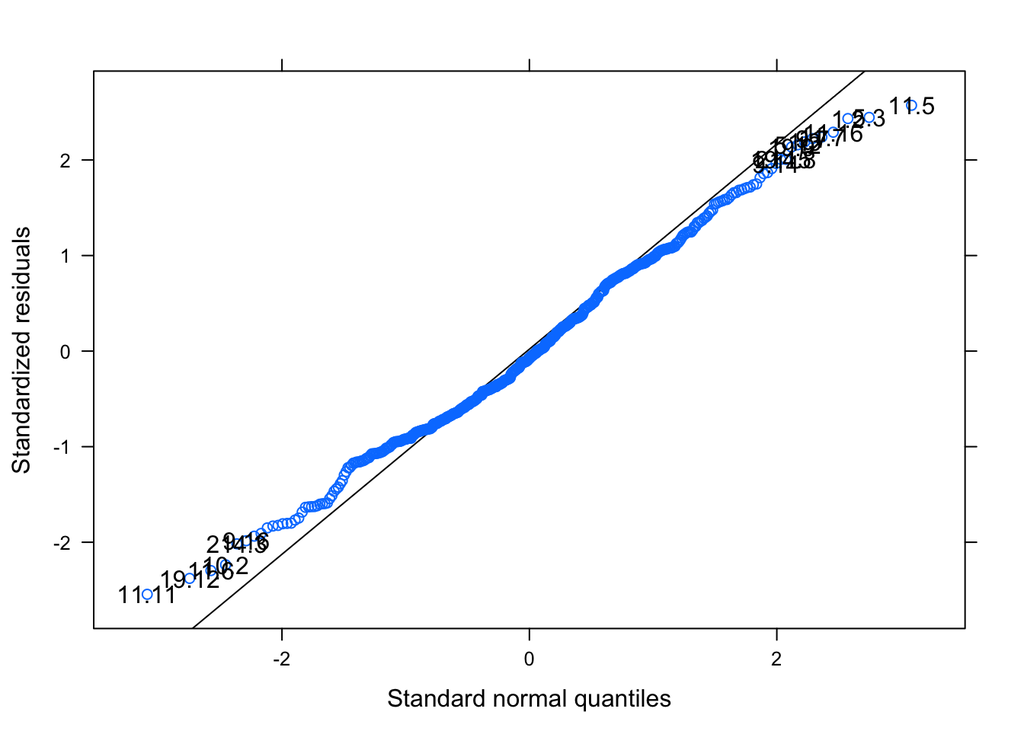

```r
qqmath(models.timing, id=0.05)
```

### All participants (Natural log)

Outcome is plain natural log of IRT

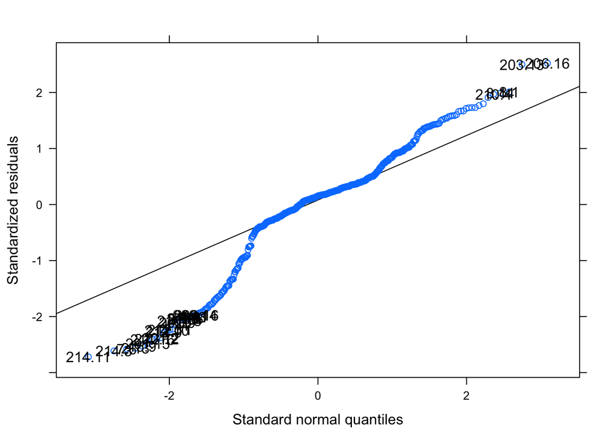

```r
qqmath(models.timingLn, id=0.05)
```

### All participants (Log 10)

Outcome is common log of IRT

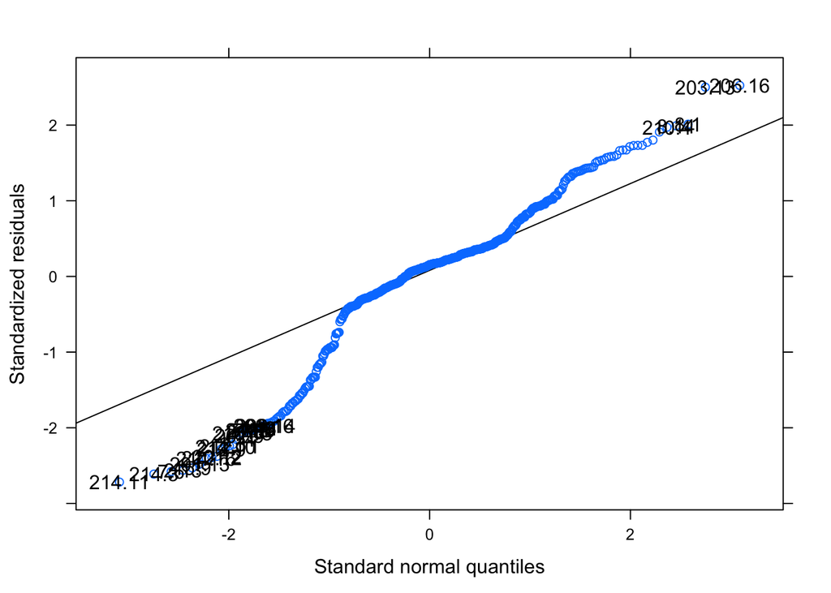

```r
qqmath(models.timingLg10, id=0.05)
```

### All participants (Inverse)

Outcome is inverse of IRT (i.e. 1/IRT)

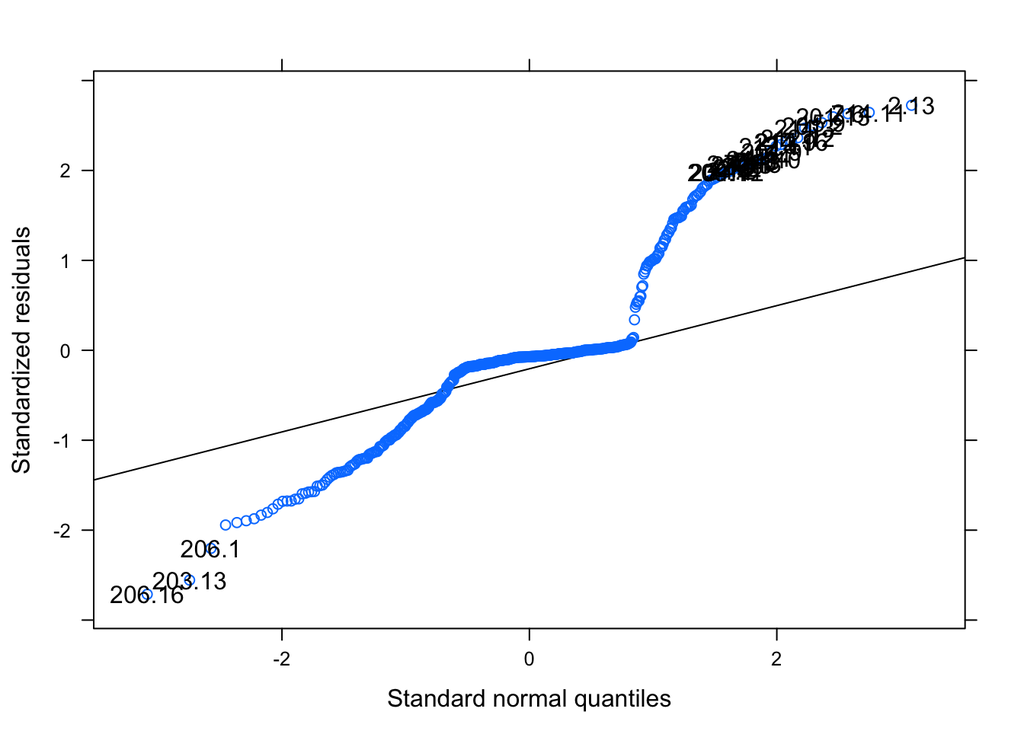

```r
qqmath(models.timingInv, id=0.05)
```

### All participants (Squared)

Outcome is IRT squared

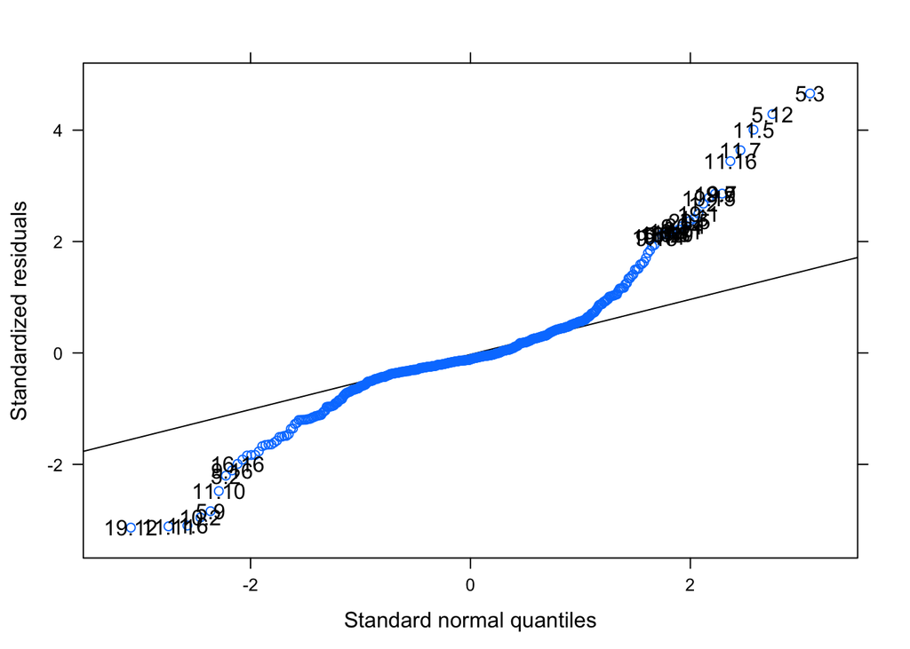

```r
qqmath(models.timingSq, id=0.05)
```

### Only GP-sensitive participants

Outcome is plain IRT, but uses subset of participants sensitive to GP

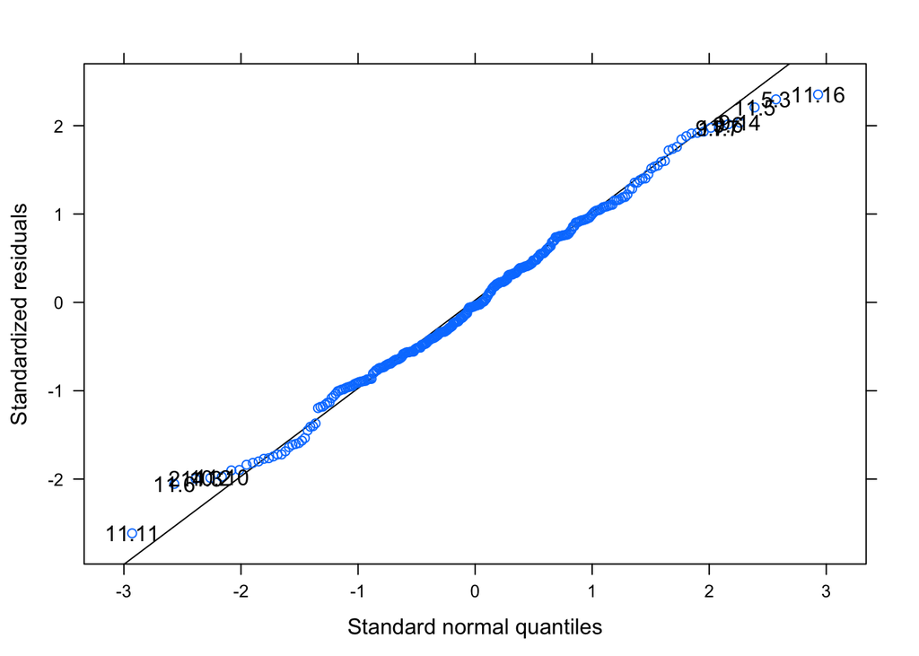

```r
qqmath(models.timing.Sense, id=0.05)
```

## Linearity

Plots of residuals vs. observed

### All Ps

Plain IRT

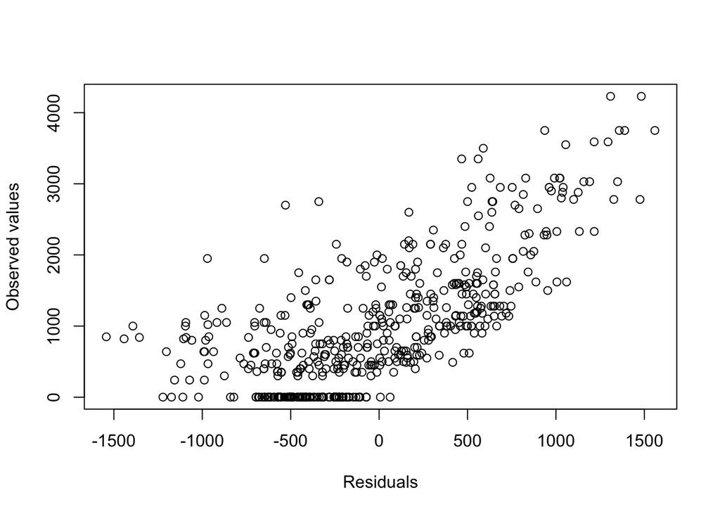

```r
plot(resid(models.timing),na.omit(inter_item_timings$inter_reading),xlab="Residuals",ylab="Observed values")
```

### All Ps (nautral log)

Natural log of IRT

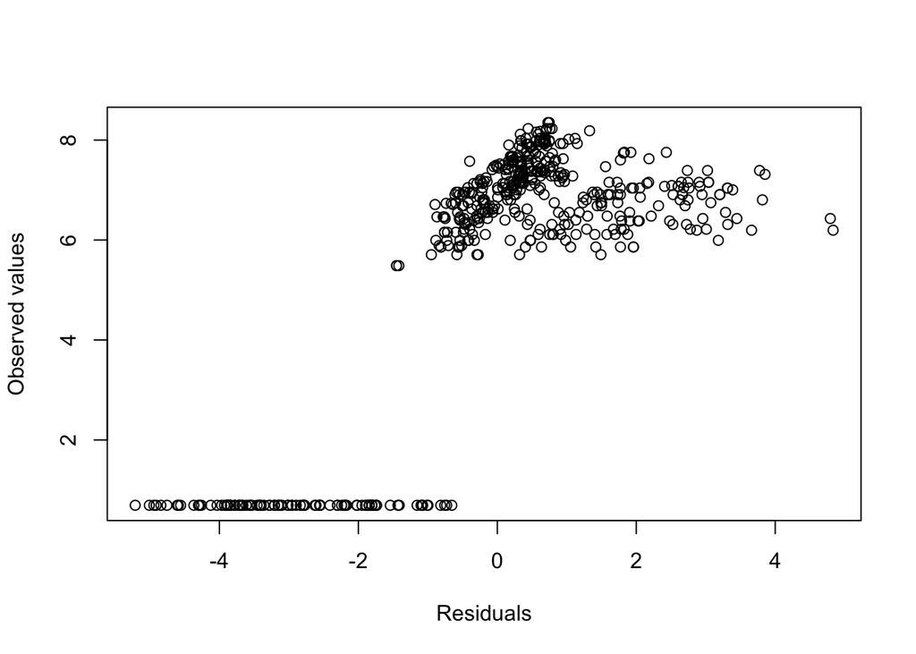

```r
plot(resid(models.timingLn),na.omit(inter_item_timings$inter_reading.ln),xlab="Residuals",ylab="Observed values")
```

### All Ps (log10)

Common log of IRT

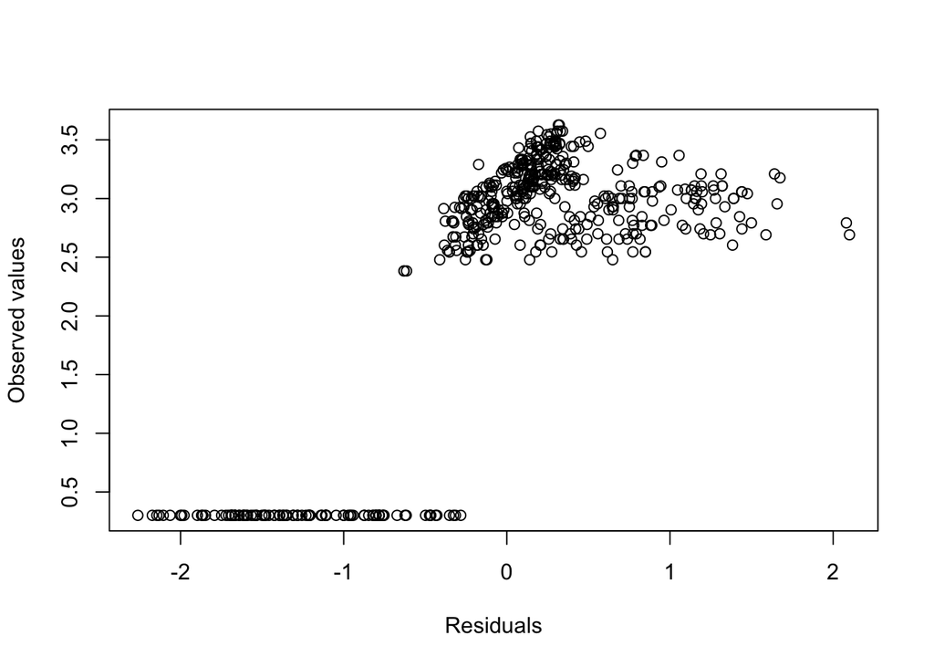

```r
plot(resid(models.timingLg10),na.omit(inter_item_timings$inter_reading.log10),xlab="Residuals",ylab="Observed values")
```

### All Ps (squared)

IRT squared

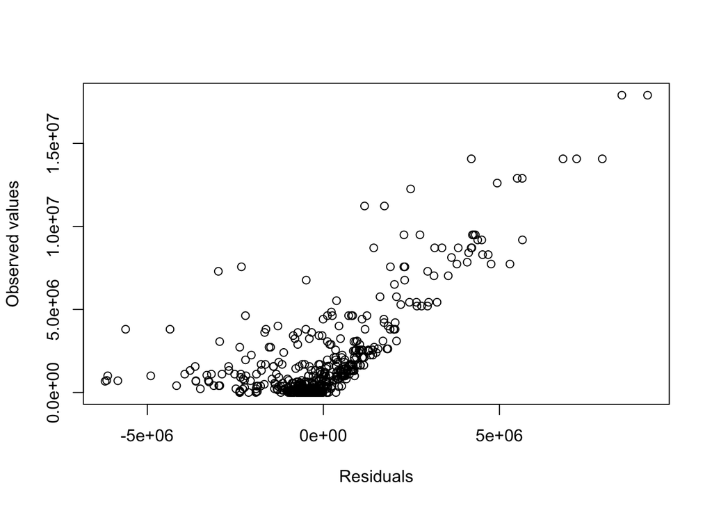

```r
plot(resid(models.timingSq),na.omit(inter_item_timings$inter_reading.sqred),xlab="Residuals",ylab="Observed values")
```

### All Ps (Inverse)

1/IRT

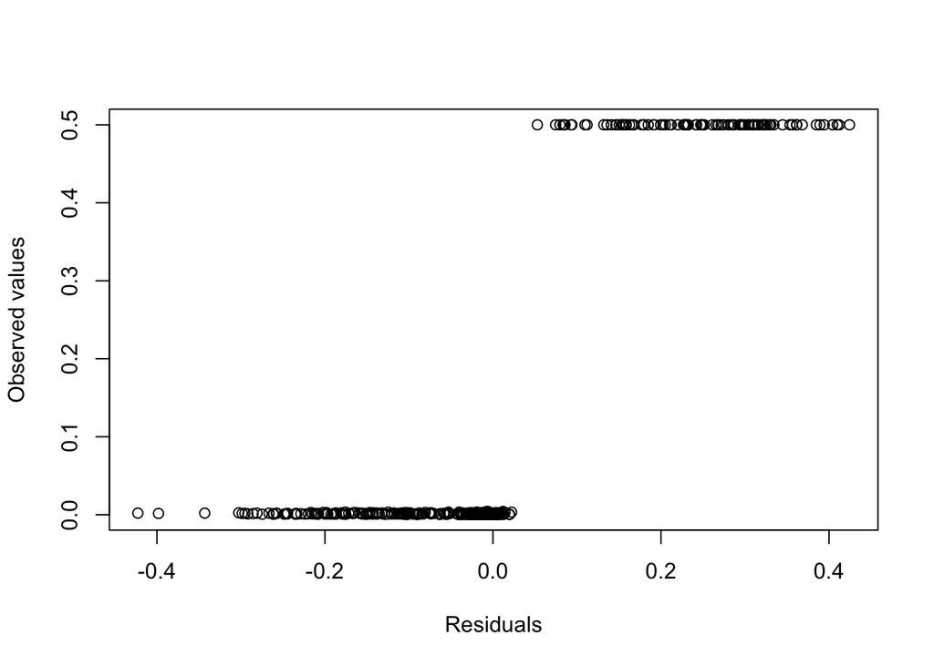

```r
plot(resid(models.timingInv),na.omit(inter_item_timings$inter_reading.inverse),xlab="Residuals",ylab="Observed values")
```

### GP-sensitive only

Subset of subjects sensitive to GP

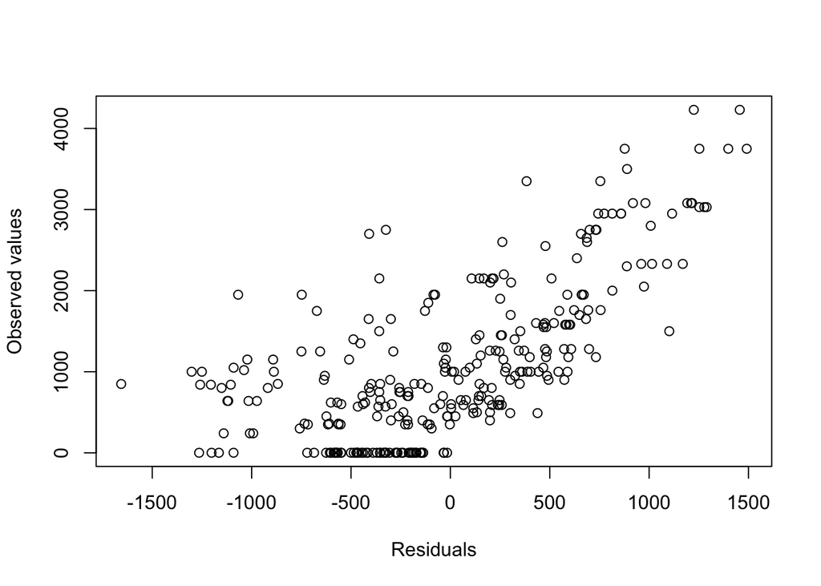

```r
plot(resid(models.timing.Sense),na.omit(sensitive_timings$inter_reading),xlab="Residuals",ylab="Observed values")
```